# GenAI: Success and Challenge

Jaykumar Patel

## Agenda

- Challenge
  - Background
  - Prompts and Results
  - Takeaways
- Success
  - Background
  - Prompts and Results
  - Takeaways
- Conclusion

# Challenge

## Background

- I want to learn how a min-heap works
  - Specifically, I am interested in mechanism for popping the minimum element
- I am a visual learner – seeing images of popping an element would be helpful
- Utilizing ChatGPT 4o

## Prompt 1

I want to learn how a min-heap works internally. Specifically, I want to learn how popping the minimum element from a min-heap works. Can you generate a sequence of images that demonstrate exactly how popping the minimum element from a min-heap works?

## Result 1

I’ll generate a sequence of images to visually demonstrate how popping the minimum element from a min-heap works. The process involves the following key steps:

1. **Initial Min-Heap**: Start with a valid min-heap.
2. **Remove the Minimum Element**: The root (smallest element) is removed.
3. **Move the Last Element to Root**: The last element in the heap replaces the root.
4. **Heapify Down (Sift Down)**: The new root is compared with its children and swapped with the smallest child until the min-heap property is restored.

I’ll generate the images now.

Here is a sequence of illustrations demonstrating how popping the minimum element from a min-heap works. The process follows these steps:

1. Start with an initial min-heap.
2. Remove the minimum element (root) and replace it with the last element in the heap.
3. Swap the new root down to restore the min-heap property.
4. Final min-heap after reordering.

Let me know if you need any clarifications!

## Result 1 - Continued

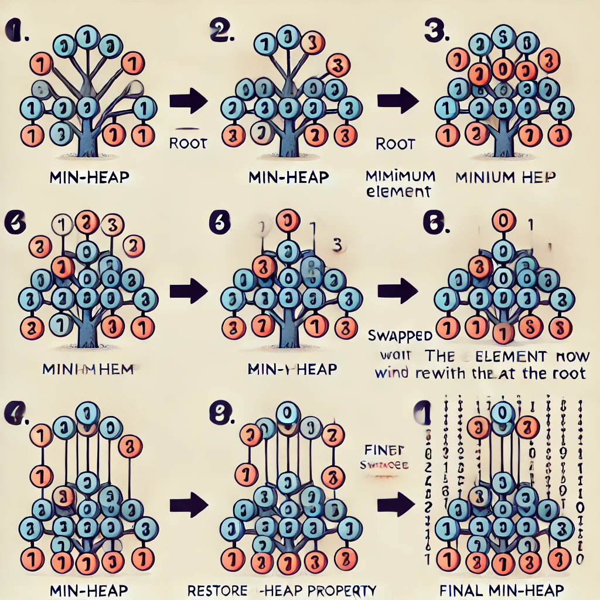

## Prompt 2

So the heap doesn’t look like a traditional heap. It looks more like a tree that you’d find in nature. Remember, the heap should look like a binary tree, where every node has at most 2 children nodes. And the root node has no parents.

## Result 2

Here is an improved step-by-step illustration of how popping the minimum element from a binary min-heap works. This version ensures that the heap is structured properly as a binary tree, where each node has at most two children. Let me know if you need any modifications or further explanations!

## Result 2 - Continued

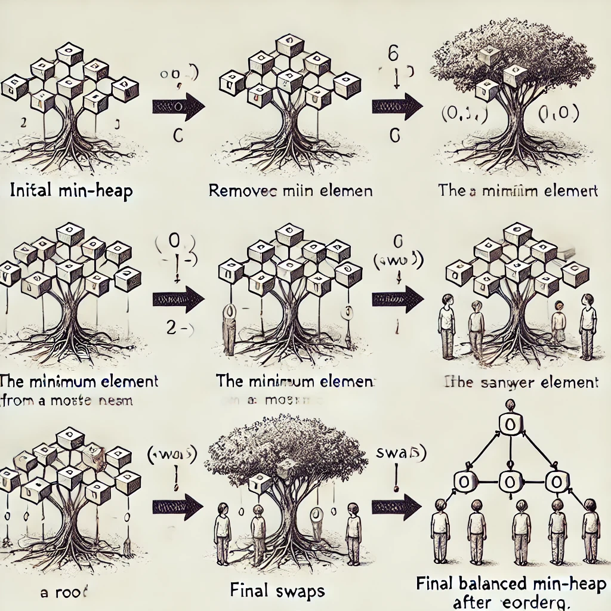

## Prompt 3

Same as before, the heaps you generated look more like trees you’d find in nature. Also, there shouldn’t be any people in your image.

Let’s start simple, instead of generating a sequence of images, can you start by first showing an image of the initial heap?

## Result 3

Here is a structured binary min-heap illustration, clearly showing the hierarchical structure where each parent node is smaller than its children. Let me know if you need any adjustments before we proceed to the next step!

## Result 3 - Continued

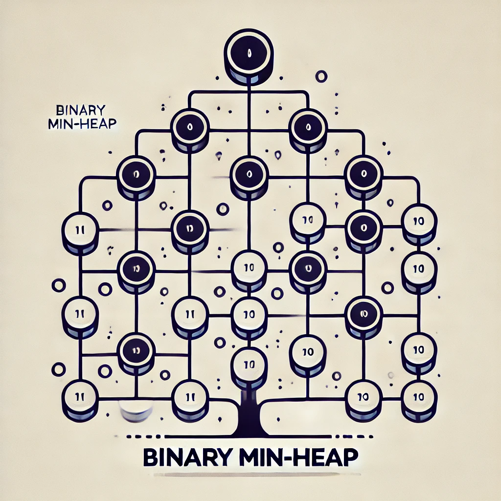

## Prompt 4

Ok that looks wrong. Let’s forget about the heap. Can you start by simply generating a binary tree? Binary tree is a data structure in Computer Science.

## Result 4

Here is a structured binary tree illustration, showing the hierarchical parent-child relationships where each node has at most two children. Let me know if this looks correct before we proceed further!

## Result 4 - Continued

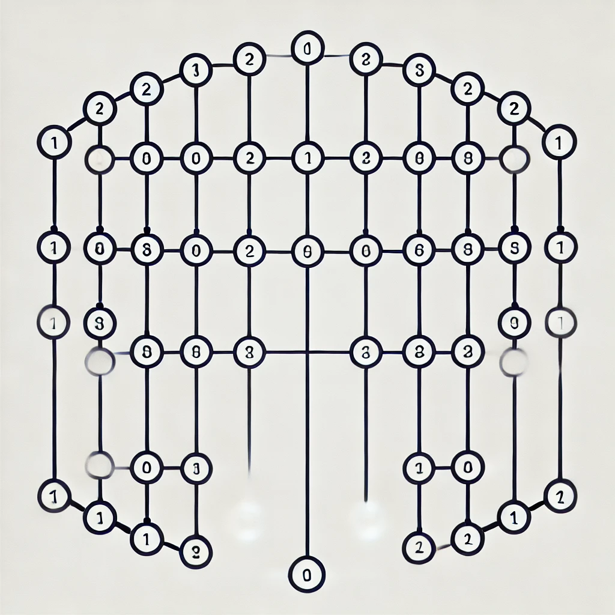

## Prompt 5

Ok remember, in a binary tree, any given node can have at most 2 children. Additionally, every node should have a parent except the root node. Can you update your image?

## Result 5

Here is an updated and correctly structured binary tree illustration. Each node follows the binary tree rules: at most two children per node, and every node (except the root) has exactly one parent. Let me know if you need further refinements!

## Result 5 - Continued

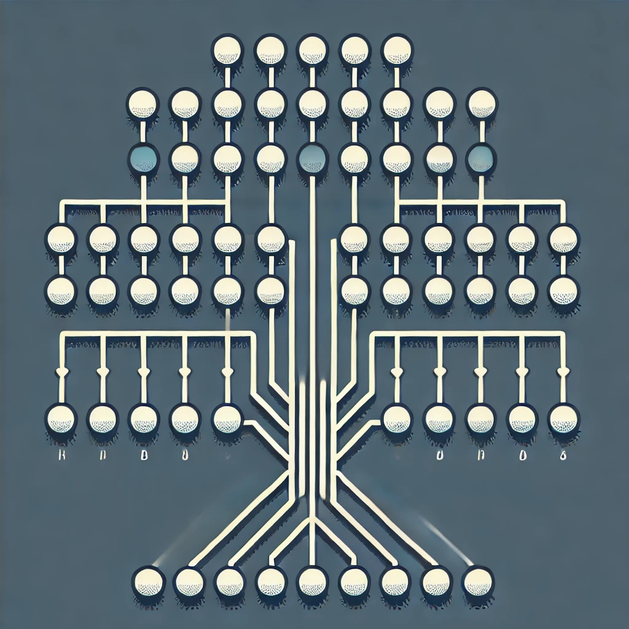

## Takeaways

- ChatGPT was not able to successfully complete the task
- Even after simplifying the task, ChatGPT was unable to generate a simple binary tree.
- The process was very iterative.
- Each step was either reattempting the previous step, or simplifying the task.

# Success

## Background

- I want to create a Streamlit frontend application to view historical stock data
- Specifically, I want to show historical earnings dates and options data
- The application should utilize an existing backend in `helper.py` to retrieve and display data
- This streamlines stock and a company’s historical performance analysis
- Utilizing ChatGPT 4o

## Prompt 1

I am creating a Streamlit application where I want to display some stock data. I already have the backend coded in a helper.py. The helper.py file contains a DataRetriever class, and its constructor takes a stock ticker as string input. Then the DataRetriever class has various methods that return data, such as stock price, earnings history, and options data.

I want your help in create a main.py which will be the Streamlit application that displays the stock data. This will be a iterative process, where I will tell you a series of tasks that build on each other.

Firstly, I don’t want everyone to be able to use this application. I want it to be password protected. Using Python, can you write me a Steamlit application where I can enter a custom password that will be used to “unlock” the rest of the application? I also don’t want the password to be visible when I am typing it on the application.

## Result 1

Here’s a basic `main.py` for your Streamlit application with password protection. It ensures that only users who enter the correct password can access the rest of the app. The password input is hidden while typing.

```python
import streamlit as st

# Define your custom password
CORRECT_PASSWORD = "your_secret_password"

# Streamlit app
st.title("Stock Data Viewer")

# Password input
password = st.text_input("Enter Password:", type="password")

# Authenticate user
if password == CORRECT_PASSWORD:
    st.success("Access granted!")
    st.write("Now you can proceed with the application.")
else:
    if password:
        st.error("Incorrect password. Please try again.")
```

This setup ensures that:

- The password is hidden while typing.
- Users see a success message if they enter the correct password.
- If the password is incorrect, they get an error message.

Let me know the next step you want to add!

## Result 1 Video

[video not shown]

## Prompt 2

Ok, now I want to add a field that takes in the Stock’s ticker as input. Can you do that?

## Result 2

Here’s an updated version of `main.py` that includes a field for entering a stock ticker after the correct password is provided:

```python
import streamlit as st

# Define your custom password
CORRECT_PASSWORD = "your_secret_password"

# Streamlit app
st.title("Stock Data Viewer")

# Password input
password = st.text_input("Enter Password:", type="password")

# Authenticate user
if password == CORRECT_PASSWORD:
    st.success("Access granted!")

    # Input for stock ticker
    ticker = st.text_input("Enter Stock Ticker:", value="", max_chars=10)

    if ticker:
        st.write(f"You entered: {ticker}")

else:
    if password:
        st.error("Incorrect password. Please try again.")
```

### Changes:

- After entering the correct password, a text input field appears for the stock ticker.
- The entered ticker is displayed below the input field.

Let me know what you want to add next!

## Result 2 Video

[video not shown]

## Prompt 3:

Great, now I want to display the stock price for the given ticker. In helper.py, the DataRetriever class has a method called getStockPrice that takes the receiver object as an input and returns the stock price. Can you create a DataRetriever object with the specified ticker, get the stock’s price, and display it on the app? I also want to ensure that if there is no ticker inputted, then there should be no stock price to display.

## Result 3:

Here’s the updated `main.py` that integrates with `helper.py` to fetch and display the stock price:

```python
import streamlit as st
from helper import DataRetriever  # Import the DataRetriever class

# Define your custom password
CORRECT_PASSWORD = "your_secret_password"

# Streamlit app
st.title("Stock Data Viewer")

# Password input
password = st.text_input("Enter Password:", type="password")

# Authenticate user
if password == CORRECT_PASSWORD:
    st.success("Access granted!")

    # Input for stock ticker
    ticker = st.text_input("Enter Stock Ticker:", value="", max_chars=10)

    if ticker:
        try:
            # Create DataRetriever object and fetch stock price
            data_retriever = DataRetriever(ticker)
            stock_price = data_retriever.getStockPrice()

            # Display stock price
            st.write(f"**Stock Price for {ticker}:** ${stock_price}")

        except Exception as e:
            st.error(f"Error fetching stock price: {e}")

else:
    if password:
        st.error("Incorrect password. Please try again.")
```

### Updates:

- Imports `DataRetriever` from `helper.py`.
- Creates a `DataRetriever` object using the provided stock ticker.
- Calls `getStockPrice()` to retrieve and display the stock price.
- Ensures that the stock price is displayed only when a ticker is entered.
- Adds error handling in case `getStockPrice()` encounters an issue.

Let me know what you want to enhance next! 🚀

## Result 3 Video

[video not shown]

## Prompt 4:

Next, I want to display the some earnings history data. Particularly, I want to display the “reportedDate” and “reportedTime” (before or after market) for previous X earnings. X should be an input that the user can enter.

DataRetriever has a method called “getEarningsHistory” which takes the number of earnings (integer) to show as an input. Thus, pass X as an integer as an input to that method. “getEarningsHistory” will return a list of tuples, containing pairs of (reportedDate, reportedTime). I want to display this as a table on the application, where the column names are “reportedDate” and “reportedTime”. Again, I want to ensure that if there is no ticker inputted, then there should be no field to enter X and no earnings history data shown on the table.

## Result 4:

Here’s the updated `main.py` that adds the earnings history display:

```python
import streamlit as st
from helper import DataRetriever  # Import the DataRetriever class
import pandas as pd  # For displaying earnings history in a table

# Define your custom password
CORRECT_PASSWORD = "your_secret_password"

# Streamlit app
st.title("Stock Data Viewer")

# Password input
password = st.text_input("Enter Password:", type="password")

# Authenticate user
if password == CORRECT_PASSWORD:
    st.success("Access granted!")

    # Input for stock ticker
    ticker = st.text_input("Enter Stock Ticker:", value="", max_chars=10)

    if ticker:
        try:
            # Create DataRetriever object
            data_retriever = DataRetriever(ticker)

            # Fetch and display stock price
            stock_price = data_retriever.getStockPrice()
            st.write(f"**Stock Price for {ticker}:** ${stock_price}")

            # Input for number of earnings history entries
            X = st.number_input("Enter number of earnings to display:", min_value=1, step=1, format="%d")

            if X:
                # Fetch earnings history
                earnings_history = data_retriever.getEarningsHistory(int(X))

                # Convert to DataFrame and display as a table
                if earnings_history:
                    df = pd.DataFrame(earnings_history, columns=["reportedDate", "reportedTime"])
                    st.table(df)
                else:
                    st.write("No earnings history available.")

        except Exception as e:
            st.error(f"Error fetching data: {e}")

else:
    if password:
        st.error("Incorrect password. Please try again.")
```

### Updates:

- Added `pandas` to format the earnings history as a table.
- Included a `number_input` field for users to specify `X`, the number of earnings entries.
- Called `getEarningsHistory(X)` to fetch earnings history.
- Displayed earnings history in a table with `reportedDate` and `reportedTime` columns.
- Ensured that the earnings input field and table only appear when a valid ticker is entered.

Let me know what you’d like to add next! 🚀

## Result 4 Video

[video not shown]

## Prompt 5:

Then, I want to display some options data. DataRetriever has a method called “getOptionsData” that takes the receiver object as an input and returns a tuple, where the first element of that tuple is the “date” for which the options data is retrieved, and the second element being the dataframe containing the stocks options data for that “date” over various expiration dates. In the dataframe that “getOptionsData” returns, there is a column called “expiration” that contains the expiration date.

I also want to display the “date” that the “getOptionsData” method returns. Also, I don’t want to display all of the dataframe at once. I want to split the options data by the expiration date. Thus for each expiration date, there should be a separate dataframe, with each dataframe labeled with its respective expiration date. Again, I want to ensure that if there is no ticker inputted, then there should be no options data shown.

## Result 5:

Here’s how you can integrate the options data display into your `main.py`. The options data will be split by expiration date and displayed separately for each expiration date:

```python
import streamlit as st
from helper import DataRetriever  # Import the DataRetriever class
import pandas as pd  # For handling and displaying dataframes

# Define your custom password
CORRECT_PASSWORD = "your_secret_password"

# Streamlit app
st.title("Stock Data Viewer")

# Password input
password = st.text_input("Enter Password:", type="password")

# Authenticate user
if password == CORRECT_PASSWORD:
    st.success("Access granted!")

    # Input for stock ticker
    ticker = st.text_input("Enter Stock Ticker:", value="", max_chars=10)

    if ticker:
        try:
            # Create DataRetriever object
            data_retriever = DataRetriever(ticker)

            # Fetch and display stock price
            stock_price = data_retriever.getStockPrice()
            st.write(f"**Stock Price for {ticker}:** ${stock_price}")

            # Input for number of earnings history entries
            X = st.number_input("Enter number of earnings to display:", min_value=1, step=1, format="%d")

            if X:
                # Fetch earnings history
                earnings_history = data_retriever.getEarningsHistory(int(X))

                # Convert to DataFrame and display as a table
                if earnings_history:
                    df = pd.DataFrame(earnings_history, columns=["reportedDate", "reportedTime"])
                    st.table(df)
                else:
                    st.write("No earnings history available.")

            # Fetch options data
            options_date, options_df = data_retriever.getOptionsData()

            if options_df is not None:
                st.write(f"**Options Data for {ticker} on {options_date}:**")

                # Split options data by expiration date and display
                expiration_dates = options_df['expiration'].unique()

                for expiration in expiration_dates:
                    st.subheader(f"Expiration Date: {expiration}")
                    expiration_data = options_df[options_df['expiration'] == expiration]
                    st.dataframe(expiration_data)
            else:
                st.write("No options data available.")

        except Exception as e:
            st.error(f"Error fetching data: {e}")

else:
    if password:
        st.error("Incorrect password. Please try again.")
```

### Updates:

- **Options Data Display**: After retrieving options data using `getOptionsData()`, I added code to split the data by `expiration` date.
- **Separate DataFrames for Expiration Dates**: For each unique expiration date in the options data, the dataframe for that expiration is displayed separately using `st.dataframe`.
- **Date of Options Data**: The date of the options data retrieval (`options_date`) is displayed at the top of the options section.
- **Handling of Missing Ticker Input**: As per your requirement, the options data is only displayed if a ticker is provided.

Let me know if you’d like to proceed with more additions or adjustments!

## Result 5 Video

[video not shown]

## Prompt 6:

Finally, for the options data, I want to highlight the “strike” column for each of the dataframes displayed. Can you do that?

## Result 6:

To highlight the “strike” column in each of the options dataframes, you can use the `st.dataframe` function along with the `applymap` styling feature in pandas. Here’s the updated version of your `main.py` that highlights the “strike” column for each expiration date:

```python
import streamlit as st
from helper import DataRetriever  # Import the DataRetriever class
import pandas as pd  # For handling and displaying dataframes

# Define your custom password
CORRECT_PASSWORD = "your_secret_password"

# Streamlit app
st.title("Stock Data Viewer")

# Password input
password = st.text_input("Enter Password:", type="password")

# Authenticate user
if password == CORRECT_PASSWORD:
    st.success("Access granted!")

    # Input for stock ticker
    ticker = st.text_input("Enter Stock Ticker:", value="", max_chars=10)

    if ticker:
        try:
            # Create DataRetriever object
            data_retriever = DataRetriever(ticker)

            # Fetch and display stock price
            stock_price = data_retriever.getStockPrice()
            st.write(f"**Stock Price for {ticker}:** ${stock_price}")

            # Input for number of earnings history entries
            X = st.number_input("Enter number of earnings to display:", min_value=1, step=1, format="%d")

            if X:
                # Fetch earnings history
                earnings_history = data_retriever.getEarningsHistory(int(X))

                # Convert to DataFrame and display as a table
                if earnings_history:
                    df = pd.DataFrame(earnings_history, columns=["reportedDate", "reportedTime"])
                    st.table(df)
                else:
                    st.write("No earnings history available.")

            # Fetch options data
            options_date, options_df = data_retriever.getOptionsData()

            if options_df is not None:
                st.write(f"**Options Data for {ticker} on {options_date}:**")

                # Split options data by expiration date and display
                expiration_dates = options_df['expiration'].unique()

                for expiration in expiration_dates:
                    st.subheader(f"Expiration Date: {expiration}")
                    expiration_data = options_df[options_df['expiration'] == expiration]

                    # Highlight the "strike" column
                    styled_df = expiration_data.style.applymap(lambda x: 'background-color: yellow', subset=['strike'])

                    # Display the styled dataframe
                    st.dataframe(styled_df)
            else:
                st.write("No options data available.")

        except Exception as e:
            st.error(f"Error fetching data: {e}")

else:
    if password:
        st.error("Incorrect password. Please try again.")
```

### Updates:

- **Highlighting the “strike” column**: I used `style.applymap` to apply a background color (`yellow`) to the “strike” column in each expiration date’s options data.
- **Displaying the styled dataframe**: `st.dataframe(styled_df)` is used to display the styled dataframe with the highlighted “strike” column.

Now, the “strike” column in each expiration date’s options data will be highlighted with a yellow background. Let me know if you’d like further adjustments!

## Result 6 Video

[video not shown]

## Takeaways

- ChatGPT was able to successfully complete the task without any issues.
- Instead of including all instructions at once, I gave ChatGPT instructions one after another, such that the solutions built on top of one another – piece by piece.
  - This is to prevent recency bias as too many instructions at once may lead to ChatGPT prioritizing the recent ones.
- The process was very iterative, with each step having very specific instructions.

## Conclusion

- ChatGPT was not able to generate a simple binary tree, let alone a min-heap.
  - It kept generating structures that either resembled real trees (trees in nature) or graphs, but not the tree data structure, even after specifying properties of the tree data structure.
  - I hypothesize that this is due to:
    - Small technical training data for image generation.
    - Images are higher dimensional. Thus, ChatGPT may be struggling to interpret the image it generated.
    - ChatGPT combined elements of real-world with CS elements to generate some abstract representation.
      - Trees in nature with the trees data structure.
      - Children (kids) with child nodes in the tree data structure.
- ChatGPT was successfully able to write the Python code to generate the frontend for my Streamlit application.
  - It did so without any errors.
  - I hypothesize that this is due to:
    - Large training data for code generation.
    - Specific and step-by-step instructions were provided.
    - The task was relatively straightforward.

### Learnings

- ChatGPT is really good at writing code. However, it struggles to generate images with exact specifications. It may interpret prompts differently than humans, combining elements to generate an abstract image.
- A tool designed for diagram generation, such as Graphviz, draw.io, and NetworkX, may be better suited.
- Specificity is important. I was able to achieve the best results, for both the challenge and success, when my prompts were specific. Being broad led to worse results.
- The process is very iterative, as ChatGPT is able to build on a solution one step at a time.